# Distribution approximation via quantiles

14:25 19 April 2016

## Stuff about splines

- `splines::interpSpline` is not very practical (it doesn’t impose monotonicity and is finicky about working with very small numbers of points)
- `graphics::xspline` is not bad, but requires adjustment of the shape parameter. The spline interpolates when shape $\leq 0$; when shape equals 0, it is a piecewise linear interpolant. When shape $<0$, is it smoother (how smooth?) but not necessarily monotonic.

## Example

```r
library(pracma)
library(splines)
library(SuppDists) ## Johnson distribution
library(plyr)     ## misc. manipulation
library(ggplot2); theme_set(theme_bw())
library(gridExtra)
n_list <- lme4:::namedList
set.seed(101)
```

```r
##' @param q quantiles (on original scale)
##' @param p probabilities [0,1]
get_aug <- function(q,p,linkfun=plogis) {
    lq <- linkfun(q) ## apply link function
    ## augment with (0,0) and (1,1)
    list(q=c(0,lq,1),p=c(0,p,1))
}
##' @param y0 CDF values
##' @param x0 response values (on link scale)
##' @param nmin minimum number of values
dfun <- function(y0,x0,
         link=plogis,  ## transform from (-inf,inf) to [0,1]
         invlink=qlogis,  ## transform from [0,1] to (-inf,inf)
         d_invlink=dlogis,
         nmin=51) {
    if (length(y0)<nmin) {
        ## linear interpolation
        x0_new <- seq(min(x0),max(x0),length=nmin)
        y0 <- approx(x0,y0,x0_new)$y
        x0 <- x0_new
    }
    a <- approxfun(y0,x0)   ## approx. inverse CDF (constrained scale)
    ## approximation of derivative (constrained scale)
    da <- approxfun((x0[-1]+x0[-length(x0)])/2,
                    diff(y0)/diff(x0))
    p <- function(q) {  ## PDF
        a(link(q))
    }
    d <- function(x,log=FALSE) {  ##
        r <- d_invlink(x)*da(link(x))
        if (log) log(r) else r
    }
    r <- function(n) {
        invlink(a(runif(n)))
    }
    list(p=p,d=d,r=r,a=a,da=da)
}
## test:
plotfun <- function(dd,n=10000,add_logist=FALSE) {
    hist(dd$r(n),main="",freq=FALSE,col="gray",breaks=100)
    curve(dd$d(x),add=TRUE,lwd=2)
    if (add_logist) curve(dlogis(x),add=TRUE,lty=2,col=2,lwd=2)
    curve(dd0$p(x),from=-5,to=5,ylim=c(0,1))
    if (add_logist) curve(plogis(x),add=TRUE,lty=2,col=2)
    return(invisible(NULL))
}
```

Use logistic distribution as a baseline, specify that the median is at 0.2 (rather than 0):

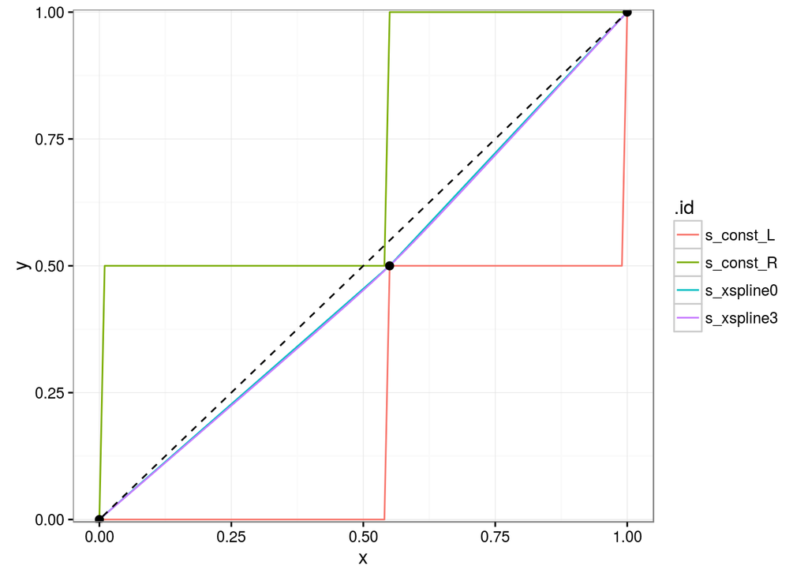

```r
aug0 <- get_aug(0.2,0.5)
plot(0:1,0:1,type="n")
s_xspline3 <- with(aug0,xspline(q,p,shape=-0.3,draw=FALSE))
s_xspline0 <- with(aug0,xspline(q,p,shape=0,draw=FALSE))
q_aug <- seq(0,1,length=101)
## pracma::spinterp doesn't work with only 3 points:
## s_pracma <- with(aug0,spinterp(q,p,xp=q_aug))
s_const_L <- with(aug0,approx(q,p,xout=q_aug,method="constant"))
s_const_R <- with(aug0,approx(q,p,xout=q_aug,method="constant",f=1))
ex1_xy <- n_list(s_xspline3,s_xspline0,s_const_L,s_const_R)
ex1_df <- ldply(ex1_xy,data.frame)  ## put the pieces together
```

```r
## compute functions based on x/y values for each spline
ex1_funs <- llply(ex1_xy,function(d) with(d,dfun(y,x)))
qx_aug <- seq(-4,4,length=101)  ## quantiles on original scale
## densities
ex1_dens <- ldply(ex1_funs,
                  function(f) data.frame(x=qx_aug,
                                         y=f$d(qx_aug)))
## cumulative dist. functions
ex1_pdf <- ldply(ex1_funs,
                  function(f) data.frame(x=qx_aug,
                                         y=f$p(qx_aug)))
## random samples
ex1_rand <- ldply(ex1_funs,
                  function(f) data.frame(x=f$r(10000)))
```

The plots look reasonable, but the constant/stepwise distribution functions reveal a bit of pathology when we look closely (the histograms of their random draws are excluded for this reason): the points at [0,1] on the link scale move off to $\pm \infty$, so disappear from the PDF and density functions …

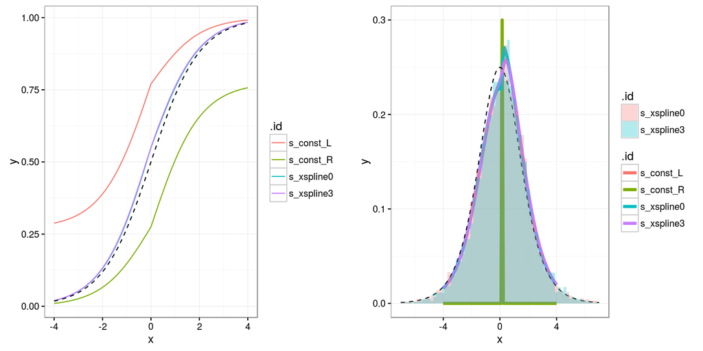

Try more quantiles:

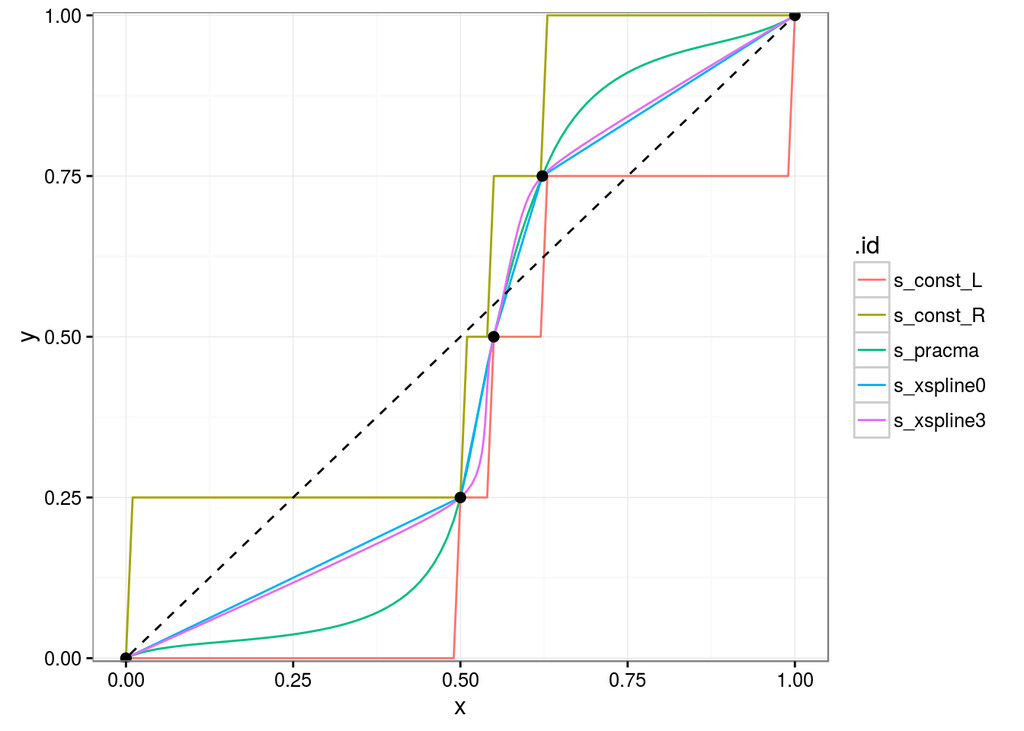

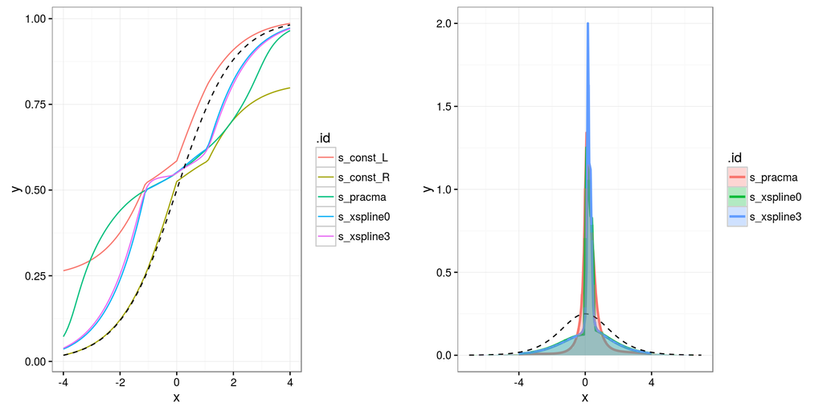

```r
plot(0:1,0:1,type="n")
aug2 <- get_aug(c(0,0.2,0.5),c(0.25,0.5,0.75))
## DRY! but good enough for now ...
s_xspline3 <- with(aug2,xspline(q,p,shape=-0.3,draw=FALSE))
s_xspline0 <- with(aug2,xspline(q,p,shape=0,draw=FALSE))
s_pracma   <- with(aug2,list(x=q_aug,y=spinterp(q,p,xp=q_aug)))
s_const_L <- with(aug2,approx(q,p,xout=q_aug,method="constant"))
s_const_R <- with(aug2,approx(q,p,xout=q_aug,method="constant",f=1))
ex2_xy <- n_list(s_xspline3,s_xspline0,s_const_L,s_const_R,s_pracma)
ex2_df <- ldply(ex2_xy,data.frame)  ## put the pieces together
```

- `gdm` package for monotonic *interpolation* splines?

Do we need the splines to be convex as well as unimodal … ?

## Johnson distributions

In principle it’s possible to estimate the parameters of a Johnson distribution from quantiles (Wheeler 1980), but it looks like the current R implementation is hard-coded based on a *specific* 5 quantiles. (Looking at the Wheeler paper I’m a bit puzzled - Wheeler selects a set of 5 symmetric quantiles, but the particular values below aren’t given. I’m not yet clear where they come from. (The code below is a *snippet* from the guts of `SuppDists::JohnsonFit()` - it doesn’t do anything by itself …)

```r
input <- quantile(t, probs = c(0.05, 0.206, 0.5, 0.794,
                               0.95), names = FALSE)
x5 <- input[[1]]
x20.6 <- input[[2]]
x50 <- input[[3]]
x79.4 <- input[[4]]
x95 <- input[[5]]
value <- .C("JohnsonFitR", as.double(x95), as.double(x79.4),
            as.double(x50), as.double(x20.6), as.double(x5),
            gamma = double(1), delta = double(1), xi = double(1),
            lambda = double(1), type = integer(1), PACKAGE = "SuppDists")
```

## References

Wheeler, Robert E. 1980. “Quantile Estimators of Johnson Curve Parameters.” *Biometrika*, 725–28. http://www.jstor.org/stable/2335153.